# Other readings

Jacob Oram

2022-12-02

# 1 (Wade 2000) Bayesian Methods in Conservation Biology

The main thrust of this article is that practitioners in conservation biology may find Bayesian methods far more appropriate for biological data, easier to handle and interpret when presenting results, with prior information explicitly incorporated to improve scientific transparency. The author first provides a simple regression example to demonstrate a situation in which Bayesian methods yield far more reasonable results (in the sense that it “matches what most people would conclude without using statistics”). The regression example is then included in a formal decision analysis, developing the loss functions directly (as opposed to defining a utility function and then defining $L = -U(\theta, a)$, which is the approach that Berger advocates for). Although this is a very simple example, it provides an excellent high-level overview of Bayesian analysis and decision theory, with a clear argument that these methods will ultimately be easier to understand and communicate when conducting conservation-oriented studies in biology and ecology.

# 2 (Williams and Hooten 2016) Combining statistical inference and decisions in ecology

The authors introduce statistical decision theory (SDT) for ecologists, noting that it has been widely applied in operations research as well as in statistics and mathematics. [In statistics, a decision rule could be a choice of estimator, such as the posterior mean; Berger (1985)]. Noting that statistics originated as a sub-branch of decision theory, and that the reemergence of the Bayesian paradigm is partly due to its natural compatability with decision theory, the authors summarize the highlights of statistical decision theory that are revelant for the field of ecology – essentially, this is briefly restating the first four chapters of Berger (1985). Following this overview, the Williams and Hooten (2016) address two classes of problems: choosing an estimator to be reported (“optimal point estimation”) and choosing a management strategy for a natural resource (“optimal resource management”). For the problem of optimal point estimation, the authors note that the correctly specifying the loss function is critical for appropriate inference.

The authors illustrate optimal resource management through an example wherein land managers must decide the burn interval to optimize cumulative abundance of Henslow’s Sparrows at Big Oaks National Wildlife Refuge in southeastern Indiana.  
This example provides a beautiful example of constructing a loss function from first principles (e.g., the statement that more frequent burn intervals are more costly and should have higher loss). The model used in the case study is

$$y_{j,t} \sim Poisson(A_j\lambda_{j,t}) \\
log(\lambda_{j,t}) = x_{j,t}\boldsymbol{\beta} + \eta_j \\$$

where $y_{j,t}$ is the count of sparrows at site $j$ during time $t$, $A_j$ is the area of site $j = 1, 2, \dots, 8$, $\lambda_{j,t}$ is the unknown density of Henslows sparrows at site $j$ during time $t$, and is a function of regression coefficients $\boldsymbol{\theta} = (\boldsymbol{\beta \eta})^T$. The covariate $x$ represents the number of summers since the last burn. The random effect $\eta_j$ is a random effect that adjusts the density of Henslows sparrows at each site. The priors for this model were

$$\boldsymbol{\beta} \sim Normal(\boldsymbol{\mu}, \sigma^2I) \\
\eta_j \sim Normal(0,1)$$

with $\mu^T = (-5, 2.5,0.2, 0.2)$ and $\sigma^2 = 10$ being informed by a prior study. The abundance over which posterior uncertainty is estimated is a derived quantity resulting from $\boldsymbol{\theta}$.

The authors’ case study utilized a standard loss function (linear loss), which is in keeping with their advice to practitioners. They acknowledge that choosing a loss function is just as subjective as choosing a likelihood and a prior, but the body of literature is many times larger for the latter two. In cases where information about potential loss is lacking, the authors suggest that standard loss functions are a good starting point. They argue that the most important aspects to consider when constructing a loss function are the shape (e.g., convex or concave) and the symmetry.

# 3 (Dorazio and Johnson 2003) Bayesian inference and decision theory: A framework for decision making in natural resource management

The authors describe the link between Bayesian methods, decision analysis and natural resource management. The introduction, which does not include the in-depth description of Bayesian decision theoretical machinery (as in Williams and Hooten 2016), makes the argument essentially for the adaptation of Bayesian methods (in general; this article is old). However, the main thrust of the article appears very similar to Williams and Hooten (2016); a key difference is that the authors provide an extended example wherein the model is autoregressive and parameter estimates are repeatedly updated over time.  
The authors discuss not only finding the expected loss for a single future time (based on the posterior predictive distribution), but also finding a sequence of optimal actions for future time steps.

Notes:

- This paper directly addresses decision making for adaptive monitoring in the sense that it focuses on an example where the same decision is repeatedly made at regular intervals. Through the sequential updating of parameter estimates over time, managers learn over time what determines optimal actions.
- The authors assume that the optimal habitat state for the hypothetical migratory birds in their example is known with certainty.
- The authors do not consider cost of management actions in their loss function.

# 4 (Varis and Kuikka 1999) Learning Bayesian decision analysis by doing: lessons from environmental and natural resources management

The authors highlight several case studies to summarize their learning from applying Bayesian decision analysis. The decision analytic frameworks they use in these case studies are based on influence diagrams and belief networks, as summarized in Varis (1997) (this work was originally developed by Judea Pearl and others in the late 1980’s). Among the lessons learned (there are many, see the discussion section), some key highlights are:

- each modification of the model structure redefines the problem
- structural uncertainty of a deterministic model can be modeled
- Bayesian decision analysis is not just parameter estimation

Some of these highlights are fairly apparent or apply outside of the BDA context. The last point seems obvious but it is interesting because it is related to a comment in a previous paper (Varis 1997): when the authors equate Bayesian decision analysis with network based methods “the entire model - *the hypothesis space* - is subjected to Bayesian analysis, not only the parameter space”. This statement makes sense when we consider that according to Berger (1985), in a hypothesis test setting the reject/FTR binary is itself a set of actions that are evaluated based on expected posterior loss. However, in the formulation of Berger (1985), the entire model is not subjected to Bayesian analysis – we still assume a likelihood function, so there is some structural input from the statistician about how the data arise. This appears to be a discrepancy between how BDA is described by Varis and Kuikka (1999) and Berger (1985).

Another source of discrepancy (or perhaps a lack of understanding on my part) arises from trying to connect networks to posterior loss. While the components of the network models match the types of situations described by Berger (1985) (e.g., an objective function, a decision to be made, an unknown state of nature with a probability distribution assigned to possible values), I haven’t formally made the connection yet with this formulation of a decision problem with minimizing posterior loss. One point of confusion for me is the arc from the random “prior” node to the final satisfaction node (see Figure 4.1). I read this arc as a statement: “if the state of nature truly is $\theta^\star$, then my satisfaction (i.e., expected loss, utility), after gathering data from screening and making a decision will be $X$.” However, in the formulation of Berger (1985), loss associated with an action is influenced by the true value of $\theta$ only through the posterior distribution, which would correspond with the three right hand arcs (from Environmental impacts to screening to EIA to satisfiction) in Figure 4.1.

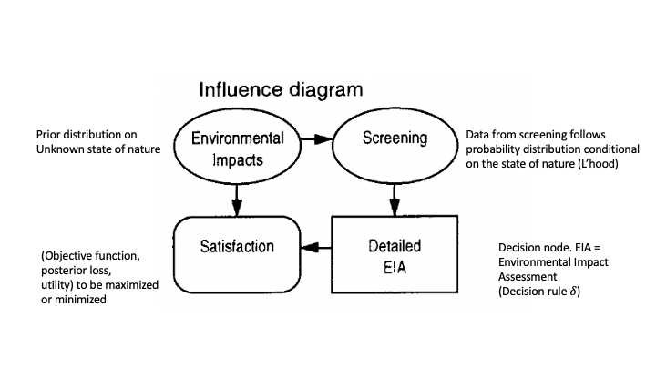

Figure 4.1: An annotated reproduction of Figure 1a from Varis (1997)

## References

Berger, James O. 1985. *Statistical Decision Theory and Bayesian Analysis*. 2nd ed. Springer Series in Statistics. New York: Springer-Verlag.

Dorazio, Robert M., and Fred A. Johnson. 2003. “BAYESIAN INFERENCE AND DECISION THEORY—a FRAMEWORK FOR DECISION MAKING IN NATURAL RESOURCE MANAGEMENT.” *Ecological Applications* 13 (2): 556–63. https://doi.org/https://doi.org/10.1890/1051-0761(2003)013[0556:BIADTA]2.0.CO;2.

Gelman, Andrew. 2013. *Bayesian Data Analysis*. 3rd ed. Chapman & Hall/CRC Texts in Statistical Science. Boca Raton, FL: Chapman; Hall/CRC, an imprint of Taylor; Francis.

Varis, Olli. 1997. “Bayesian Decision Analysis for Environmental and Resource Management.” *Environmental Modelling & Software* 12 (2): 177–85. https://doi.org/https://doi.org/10.1016/S1364-8152(97)00008-X.

Varis, Olli, and Sakari Kuikka. 1999. “Learning Bayesian Decision Analysis by Doing: Lessons from Environmental and Natural Resources Management.” *Ecological Modelling* 119 (2): 177–95. https://doi.org/https://doi.org/10.1016/S0304-3800(99)00061-7.

Wade, Paul R. 2000. “Bayesian Methods in Conservation Biology.” *Conservation Biology* 14 (5): 1308–16. https://doi.org/https://doi.org/10.1046/j.1523-1739.2000.99415.x.

Williams, Perry J., and Mevin B. Hooten. 2016. “Combining Statistical Inference and Decisions in Ecology.” *Ecological Applications* 26 (6): 1930–42. https://doi.org/https://doi.org/10.1890/15-1593.1.